# Data Science Using Python, SAS, & R

A Rosetta Stone for Analytical Languages

Elaine Kearney

# Python Tutorial

pandas (0.20.2) | NumPy (1.12.1) | Matplotlib.PyPlot | seaborn (0.7.1) | re (2.2.1) | decimal (1.70) | sklearn (0.18.2) | statsmodels.api | xgboost (0.6) | pyclustering | PyFlux (0.4.15) | fbprophet

To install Python packages you will often need to run the following code from a terminal/command line on your computer, and then later in a Python environment you will import the package, which is demonstrated in this tutorial:

```python
pip install package_name
# or #
conda install package_name
```

Note: In Python, comments are indicated in code with a “#” character, and arrays and matrices are zero-indexed.

Now let’s get started! First, you need to import several very important Python packages for data manipulation and scientific computing. The pandas package is useful for data manipulation and the NumPy package is useful for scientific computing.

```python
import pandas as pd
import numpy as np
```

# 1 Reading in Data and Basic Statistical Functions

## 1.1 Read in the data.

The following demonstrate importing data into Python given 3 different file formats. The pandas package is able to read all 3 formats, as well as many others, using [Python IO tools](http://pandas.pydata.org/pandas-docs/version/0.20/io.html).

### a) Read the data in as a .csv file.

```python
student = pd.read_csv('/Users/class.csv')
```

### b) Read the data in as a .xls file.

```python
# Notice you must specify the file location, as well as the name of the sheet
# of the .xls file you want to import
student_xls = pd.read_excel(open('/Users/class.xls', 'rb'),
                            sheetname='class')
```

### c) Read the data in as a .json file.

```python
student_json = pd.read_json('/Users/class.json')
```

## 1.2 Find the dimensions of the data set.

The dimensions of a DataFrame in Python are known as an attribute of the object. Therefore, you can state the data name followed by [.shape](http://pandas.pydata.org/pandas-docs/version/0.17.0/generated/pandas.DataFrame.shape.html) to return the dimensions of the data, with the first integer indicating the number of rows and the second indicating the number of columns.

```python
print(student.shape)
```

```
## (19, 5)
```

## 1.3 Find basic information about the data set.

Information about a DataFrame is available by calling the [info()](https://pandas.pydata.org/pandas-docs/stable/generated/pandas.DataFrame.info.html) function on the data.

```python
print(student.info())
```

```
## <class 'pandas.core.frame.DataFrame'>
## RangeIndex: 19 entries, 0 to 18
## Data columns (total 5 columns):
## Name      19 non-null object
## Sex       19 non-null object
## Age       19 non-null int64
## Height    19 non-null float64
## Weight    19 non-null float64
## dtypes: float64(2), int64(1), object(2)
## memory usage: 840.0+ bytes
## None
```

## 1.4 Look at the first 5 (last 5) observations.

The first 5 observations of a DataFrame are available by calling the [head()](https://pandas.pydata.org/pandas-docs/stable/generated/pandas.DataFrame.head.html) function on the data. By default, head() returns 5 observations. To return the first *n* observations, pass the integer *n* into the function. The [tail()](https://pandas.pydata.org/pandas-docs/stable/generated/pandas.DataFrame.tail.html) function is analogous and returns the last observations.

```python
print(student.head())
```

```
##       Name Sex  Age  Height  Weight
## 0   Alfred   M   14    69.0   112.5
## 1    Alice   F   13    56.5    84.0
## 2  Barbara   F   13    65.3    98.0
## 3    Carol   F   14    62.8   102.5
## 4    Henry   M   14    63.5   102.5
```

## 1.5 Calculate means of numeric variables.

The means of numeric variables of a DataFrame are available by calling the [mean()](https://pandas.pydata.org/pandas-docs/stable/generated/pandas.DataFrame.mean.html) function on the data.

```python
print(student.mean())
```

```
## Age        13.315789
## Height     62.336842
## Weight    100.026316
## dtype: float64
```

## 1.6 Compute summary statistics of the data set.

Summary statistics of a DataFrame are available by calling the [describe()](https://pandas.pydata.org/pandas-docs/stable/generated/pandas.DataFrame.describe.html) function on the data.

```python
print(student.describe())
```

```
##              Age     Height      Weight
## count  19.000000  19.000000   19.000000
## mean   13.315789  62.336842  100.026316
## std     1.492672   5.127075   22.773933
## min    11.000000  51.300000   50.500000
## 25%    12.000000  58.250000   84.250000
## 50%    13.000000  62.800000   99.500000
## 75%    14.500000  65.900000  112.250000
## max    16.000000  72.000000  150.000000
```

## 1.7 Descriptive statistics functions applied to variables of the data set.

```python
# Notice the subsetting of student with [] and the name of the variable in
# quotes ("")
print(student["Weight"].std())
```

```
## 22.773933493879046
```

```python
print(student["Weight"].sum())
```

```
## 1900.5
```

```python
print(student["Weight"].count())
```

```
## 19
```

```python
print(student["Weight"].max())
```

```
## 150.0
```

```python
print(student["Weight"].min())
```

```
## 50.5
```

```python
print(student["Weight"].median())
```

```
## 99.5
```

## 1.8 Produce a one-way table to describe the frequency of a variable.

### a) Produce a one-way table of a discrete variable.

```python
# columns = "count" indicates to make the descriptive portion of the table
# the counts of each level of the index variable
print(pd.crosstab(index=student["Age"], columns="count"))
```

```
## col_0  count
## Age
## 11         2
## 12         5
## 13         3
## 14         4
## 15         4
## 16         1
```

### b) Produce a one-way table of a categorical variable.

```python
print(pd.crosstab(index=student["Sex"], columns="count"))
```

```
## col_0  count
## Sex
## F          9
## M         10
```

[pd.crosstab()](https://pandas.pydata.org/pandas-docs/stable/generated/pandas.crosstab.html)

## 1.9 Produce a two-way table to describe the frequency of two categorical or discrete variables.

```python
# Notice the specification of a variable for the columns argument, instead
# of "count"
print(pd.crosstab(index=student["Age"], columns=student["Sex"]))
```

```
## Sex  F  M
## Age
## 11   1  1
## 12   2  3
## 13   2  1
## 14   2  2
## 15   2  2
## 16   0  1
```

[pd.crosstab()](https://pandas.pydata.org/pandas-docs/stable/generated/pandas.crosstab.html)

## 1.10 Select a subset of the data that meets a certain criterion.

```python
females = student.query('Sex == "F"')
print(females.head())
```

```
##       Name Sex  Age  Height  Weight
## 1    Alice   F   13    56.5    84.0
## 2  Barbara   F   13    65.3    98.0
## 3    Carol   F   14    62.8   102.5
## 6     Jane   F   12    59.8    84.5
## 7    Janet   F   15    62.5   112.5
```

[query()](http://pandas.pydata.org/pandas-docs/stable/generated/pandas.DataFrame.query.html)

## 1.11 Determine the correlation between two continuous variables.

```python
# axis = 1 option indicates to concatenate column-wise
height_weight = pd.concat([student["Height"], student["Weight"]], axis = 1)
print(height_weight.corr(method = "pearson"))
```

```
##           Height    Weight
## Height  1.000000  0.877785
## Weight  0.877785  1.000000
```

[pd.concat()](http://pandas.pydata.org/pandas-docs/version/0.20/generated/pandas.concat.html) | [corr()](https://pandas.pydata.org/pandas-docs/stable/generated/pandas.DataFrame.corr.html)

# 2 Basic Graphing and Plotting Functions

The Matplotlib PyPlot package is a standard Python package to use for plotting. For more information on other Python plotting packages, please see the Appendix Section 2.

```python
import matplotlib.pyplot as plt
```

## 2.1 Visualize a single continuous variable by producing a histogram.

```python
# Notice the labeling of the axes
plt.hist(student["Weight"], bins=[40,60,80,100,120,140,160])
plt.xlabel('Weight')
plt.ylabel('Frequency')
plt.show()
```

Output:

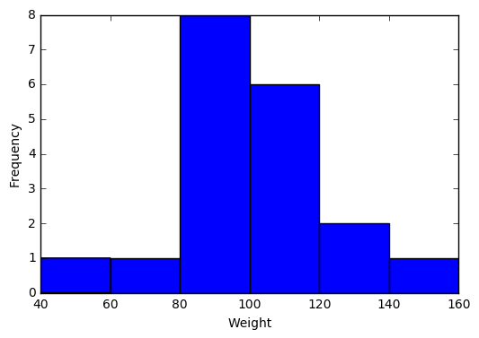

## 2.2 Visualize a single continuous variable by producing a boxplot.

```python
# showmeans=True tells Python to plot the mean of the variable on the boxplot
plt.boxplot(student["Weight"], showmeans=True)

# prevents Python from printing a "1" at the bottom of the boxplot
plt.xticks([])

plt.ylabel('Weight')
plt.show()
```

Output:

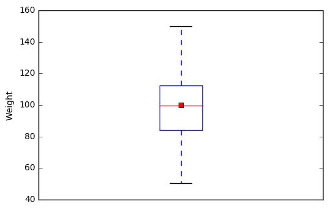

## 2.3 Visualize two continuous variables by producing a scatterplot.

```python
# Notice here you specify the x variable, followed by the y variable
plt.scatter(student["Height"], student["Weight"])
plt.xlabel("Height")
plt.ylabel("Weight")
plt.show()
```

Output:

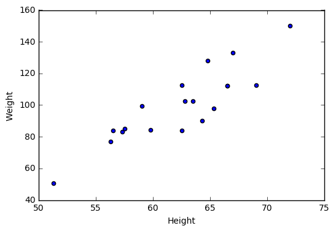

## 2.4 Visualize a relationship between two continuous variables by producing a scatterplot and a plotted line of best fit.

```python
x = student["Height"]
y = student["Weight"]

# np.polyfit() models Weight as a function of Height and returns the
# parameters
m, b = np.polyfit(x, y, 1)
plt.scatter(x, y)

# plt.text() prints the equation of the line of best fit, with the first two
# arguments specifying the x and y locations of the text, respectively
# "%f" indicates to print a floating point number, that is specified following
# the string and a "%" character
plt.text(51, 140, "Line: y = %f x + %f"% (m,b))
plt.plot(x, m*x + b)
plt.xlabel("Height")
plt.ylabel("Weight")
plt.show()
```

Output:

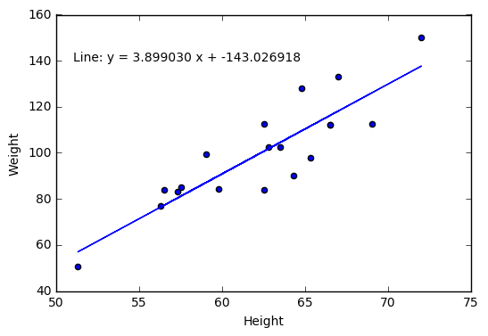

[np.polyfit()](https://docs.scipy.org/doc/numpy/reference/generated/numpy.polyfit.html)

## 2.5 Visualize a categorical variable by producing a bar chart.

```python
# Get the counts of Sex
counts = pd.crosstab(index=student["Sex"], columns="count")

# len() returns the number of categories of Sex (2)
# np.arange() creates a vector of the specified length
num = np.arange(len(counts))

# alpha = 0.5 changes the transparency of the bars
plt.bar(num, counts["count"], align='center', alpha=0.5)

# Set the xticks to be the indices of counts
plt.xticks(num, counts.index)
plt.xlabel("Sex")
plt.ylabel("Frequency")
plt.show()
```

Output:

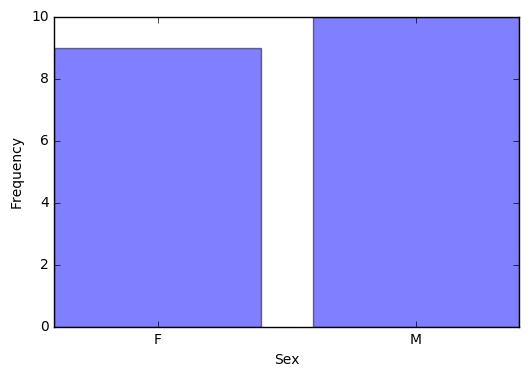

[np.arange()](https://docs.scipy.org/doc/numpy/reference/generated/numpy.arange.html)

## 2.6 Visualize a continuous variable, grouped by a categorical variable, by producing side-by-side boxplots.

### a) Simple side-by-side boxplot without color.

```python
# Subset data set to return only female weights, and then only male weights
Weight_F = np.array(student.query('Sex == "F"')["Weight"])
Weight_M = np.array(student.query('Sex == "M"')["Weight"])
Weights = [Weight_F, Weight_M]

# PyPlot automatically plots the two weights side-by-side since Weights
# is a 2D array
plt.boxplot(Weights, showmeans=True, labels=('F', 'M'))
plt.xlabel('Sex')
plt.ylabel('Weight')
plt.show()
```

Output:

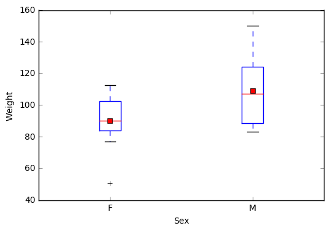

[np.array()](https://docs.scipy.org/doc/numpy/reference/generated/numpy.array.html)

### b) More advanced side-by-side boxplot with color.

```python
import seaborn as sns
sns.boxplot(x="Sex", y="Weight", hue="Sex", data = student, showmeans=True)
sns.plt.show()
```

Output:

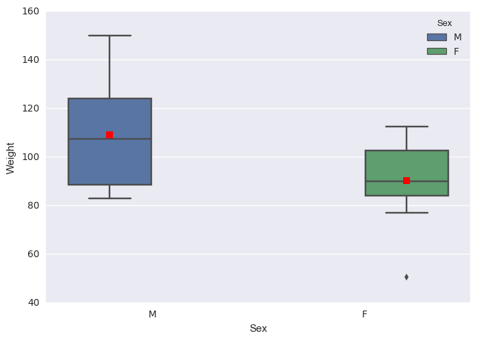

seaborn

# 3 Basic Data Wrangling and Manipulation

## 3.1 Create a new variable in a data set as a function of existing variables in the data set.

```python
# Notice here how you can create the BMI column in the data set
# just by naming it
student["BMI"] = student["Weight"] / student["Height"]**2 * 703
print(student.head())
```

```
##       Name Sex  Age  Height  Weight        BMI
## 0   Alfred   M   14    69.0   112.5  16.611531
## 1    Alice   F   13    56.5    84.0  18.498551
## 2  Barbara   F   13    65.3    98.0  16.156788
## 3    Carol   F   14    62.8   102.5  18.270898
## 4    Henry   M   14    63.5   102.5  17.870296
```

## 3.2 Create a new variable in a data set using if/else logic of existing variables in the data set.

```python
# Notice the use of the np.where() function for a single condition
student["BMI Class"] = np.where(student["BMI"] < 19.0, "Underweight",
                                "Healthy")
print(student.head())
```

```
##       Name Sex  Age  Height  Weight        BMI    BMI Class
## 0   Alfred   M   14    69.0   112.5  16.611531  Underweight
## 1    Alice   F   13    56.5    84.0  18.498551  Underweight
## 2  Barbara   F   13    65.3    98.0  16.156788  Underweight
## 3    Carol   F   14    62.8   102.5  18.270898  Underweight
## 4    Henry   M   14    63.5   102.5  17.870296  Underweight
```

[np.where()](https://docs.scipy.org/doc/numpy/reference/generated/numpy.where.html)

## 3.3 Create new variables in a data set using mathematical functions applied to existing variables in the data set.

Using the [np.log()](https://docs.scipy.org/doc/numpy/reference/generated/numpy.log.html), [np.exp()](https://docs.scipy.org/doc/numpy/reference/generated/numpy.exp.html), [np.sqrt()](https://docs.scipy.org/doc/numpy/reference/generated/numpy.sqrt.html), [np.where()](https://docs.scipy.org/doc/numpy/reference/generated/numpy.where.html), and [np.abs()](https://docs.scipy.org/doc/numpy/reference/generated/numpy.absolute.html) functions.

```python
student["LogWeight"] = np.log(student["Weight"])
student["ExpAge"] = np.exp(student["Age"])
student["SqrtHeight"] = np.sqrt(student["Height"])
student["BMI Neg"] = np.where(student["BMI"] < 19.0, -student["BMI"],
                              student["BMI"])
student["BMI Pos"] = np.abs(student["BMI Neg"])

# Create a Boolean variable
student["BMI Check"] = (student["BMI Pos"] == student["BMI"])
```

[output not shown]

## 3.4 Drop variables from a data set.

```python
# axis = 1 indicates to drop columns instead of rows
student = student.drop(["LogWeight", "ExpAge", "SqrtHeight", "BMI Neg",
                        "BMI Pos", "BMI Check"], axis = 1)
print(student.head())
```

```
##       Name Sex  Age  Height  Weight        BMI    BMI Class
## 0   Alfred   M   14    69.0   112.5  16.611531  Underweight
## 1    Alice   F   13    56.5    84.0  18.498551  Underweight
## 2  Barbara   F   13    65.3    98.0  16.156788  Underweight
## 3    Carol   F   14    62.8   102.5  18.270898  Underweight
## 4    Henry   M   14    63.5   102.5  17.870296  Underweight
```

[drop()](https://pandas.pydata.org/pandas-docs/stable/generated/pandas.DataFrame.drop.html)

## 3.5 Sort a data set by a variable.

### a) Sort data set by a continuous variable.

```python
# Notice kind="mergesort" which indicates to use a stable sorting
# algorithm
student = student.sort_values(by="Age", kind="mergesort")
print(student.head())
```

```
##       Name Sex  Age  Height  Weight        BMI    BMI Class
## 10   Joyce   F   11    51.3    50.5  13.490001  Underweight
## 17  Thomas   M   11    57.5    85.0  18.073346  Underweight
## 5    James   M   12    57.3    83.0  17.771504  Underweight
## 6     Jane   F   12    59.8    84.5  16.611531  Underweight
## 9     John   M   12    59.0    99.5  20.094369      Healthy
```

### b) Sort data set by a categorical variable.

```python
student = student.sort_values(by="Sex", kind="mergesort")
# Notice that the data is now sorted first by Sex and then within Sex by Age
print(student.head())
```

```
##        Name Sex  Age  Height  Weight        BMI    BMI Class
## 10    Joyce   F   11    51.3    50.5  13.490001  Underweight
## 6      Jane   F   12    59.8    84.5  16.611531  Underweight
## 12   Louise   F   12    56.3    77.0  17.077695  Underweight
## 1     Alice   F   13    56.5    84.0  18.498551  Underweight
## 2   Barbara   F   13    65.3    98.0  16.156788  Underweight
```

[sort_values()](https://pandas.pydata.org/pandas-docs/stable/generated/pandas.DataFrame.sort_values.html)

## 3.6 Compute descriptive statistics of continuous variables, grouped by a categorical variable.

```python
print(student.groupby(by="Sex").mean())
```

```
##            Age     Height      Weight        BMI
## Sex
## F    13.222222  60.588889   90.111111  17.051039
## M    13.400000  63.910000  108.950000  18.594243
```

[groupby()](https://pandas.pydata.org/pandas-docs/stable/generated/pandas.DataFrame.groupby.html)

## 3.7 Add a new row to the bottom of a data set.

```python
# Look at the tail of the data currently
print(student.tail())
```

```
##        Name Sex  Age  Height  Weight        BMI    BMI Class
## 0    Alfred   M   14    69.0   112.5  16.611531  Underweight
## 4     Henry   M   14    63.5   102.5  17.870296  Underweight
## 16   Ronald   M   15    67.0   133.0  20.828470      Healthy
## 18  William   M   15    66.5   112.0  17.804511  Underweight
## 14   Philip   M   16    72.0   150.0  20.341435      Healthy
```

```python
student = student.append({'Name':'Jane', 'Sex':'F', 'Age':14, 'Height':56.3,
                          'Weight':77.0, 'BMI':17.077695,
                          'BMI Class': 'Underweight'},
                         ignore_index=True)

# Notice the change in the indices because of the ignore_index=True option
# which allows for a Series, or one-dimensional DataFrame, to be appended
# to an existing DataFrame
```

[output not shown]

[append()](https://pandas.pydata.org/pandas-docs/stable/generated/pandas.DataFrame.append.html)

## 3.8 Create a user-defined function and apply it to a variable in the data set to create a new variable in the data set.

```python
def toKG(lb):
    return (0.45359237 * lb)

student["Weight KG"] = student["Weight"].apply(toKG)
print(student.head())
```

```
##       Name Sex  Age  Height  Weight        BMI    BMI Class  Weight KG
## 0    Joyce   F   11    51.3    50.5  13.490001  Underweight  22.906415
## 1     Jane   F   12    59.8    84.5  16.611531  Underweight  38.328555
## 2   Louise   F   12    56.3    77.0  17.077695  Underweight  34.926612
## 3    Alice   F   13    56.5    84.0  18.498551  Underweight  38.101759
## 4  Barbara   F   13    65.3    98.0  16.156788  Underweight  44.452052
```

[apply()](https://pandas.pydata.org/pandas-docs/stable/generated/pandas.DataFrame.apply.html) | [user-defined functions](https://www.tutorialspoint.com/python/python_functions.htm)

# 4 More Advanced Data Wrangling

## 4.1 Drop observations with missing information.

```python
# Notice the use of the fish data set because it has some missing
# observations
fish = pd.read_csv('/Users/fish.csv')

# First sort by Weight, requesting those with NA for Weight first
fish = fish.sort_values(by='Weight', kind='mergesort', na_position='first')
print(fish.head())
```

```
##     Species  Weight  Length1  Length2  Length3   Height   Width
## 13    Bream     NaN     29.5     32.0     37.3  13.9129  5.0728
## 40    Roach     0.0     19.0     20.5     22.8   6.4752  3.3516
## 72    Perch     5.9      7.5      8.4      8.8   2.1120  1.4080
## 145   Smelt     6.7      9.3      9.8     10.8   1.7388  1.0476
## 147   Smelt     7.0     10.1     10.6     11.6   1.7284  1.1484
```

–

```python
new_fish = fish.dropna()
print(new_fish.head())
```

```
##     Species  Weight  Length1  Length2  Length3  Height   Width
## 40    Roach     0.0     19.0     20.5     22.8  6.4752  3.3516
## 72    Perch     5.9      7.5      8.4      8.8  2.1120  1.4080
## 145   Smelt     6.7      9.3      9.8     10.8  1.7388  1.0476
## 147   Smelt     7.0     10.1     10.6     11.6  1.7284  1.1484
## 146   Smelt     7.5     10.0     10.5     11.6  1.9720  1.1600
```

[dropna()](http://pandas.pydata.org/pandas-docs/stable/generated/pandas.DataFrame.dropna.html)

## 4.2 Merge two data sets together on a common variable.

### a) First, select specific columns of a data set to create two smaller data sets.

```python
# Notice the use of the student data set again, however we want to reload it
# without the changes we've made previously
student = pd.read_csv('/Users/class.csv')
student1 = pd.concat([student["Name"], student["Sex"], student["Age"]],
                    axis = 1)
print(student1.head())
```

```
##       Name Sex  Age
## 0   Alfred   M   14
## 1    Alice   F   13
## 2  Barbara   F   13
## 3    Carol   F   14
## 4    Henry   M   14
```

–

```python
student2 = pd.concat([student["Name"], student["Height"], student["Weight"]],
                    axis = 1)
print(student2.head())
```

```
##       Name  Height  Weight
## 0   Alfred    69.0   112.5
## 1    Alice    56.5    84.0
## 2  Barbara    65.3    98.0
## 3    Carol    62.8   102.5
## 4    Henry    63.5   102.5
```

### b) Second, we want to merge the two smaller data sets on the common variable.

```python
new = pd.merge(student1, student2, on="Name")
print(new.head())
```

```
##       Name Sex  Age  Height  Weight
## 0   Alfred   M   14    69.0   112.5
## 1    Alice   F   13    56.5    84.0
## 2  Barbara   F   13    65.3    98.0
## 3    Carol   F   14    62.8   102.5
## 4    Henry   M   14    63.5   102.5
```

[pd.merge()](https://pandas.pydata.org/pandas-docs/stable/generated/pandas.DataFrame.merge.html)

### c) Finally, we want to check to see if the merged data set is the same as the original data set.

```python
print(student.equals(new))
```

```
## True
```

[equals()](https://pandas.pydata.org/pandas-docs/stable/generated/pandas.DataFrame.equals.html)

## 4.3 Merge two data sets together by index number only.

### a) First, select specific columns of a data set to create two smaller data sets.

```python
newstudent1 = pd.concat([student["Name"], student["Sex"], student["Age"]],
                        axis = 1)
print(newstudent1.head())
```

```
##       Name Sex  Age
## 0   Alfred   M   14
## 1    Alice   F   13
## 2  Barbara   F   13
## 3    Carol   F   14
## 4    Henry   M   14
```

–

```python
newstudent2 = pd.concat([student["Height"], student["Weight"]], axis = 1)
print(newstudent2.head())
```

```
##    Height  Weight
## 0    69.0   112.5
## 1    56.5    84.0
## 2    65.3    98.0
## 3    62.8   102.5
## 4    63.5   102.5
```

### b) Second, we want to join the two smaller data sets.

```python
new2 = newstudent1.join(newstudent2)
print(new2.head())
```

```
##       Name Sex  Age  Height  Weight
## 0   Alfred   M   14    69.0   112.5
## 1    Alice   F   13    56.5    84.0
## 2  Barbara   F   13    65.3    98.0
## 3    Carol   F   14    62.8   102.5
## 4    Henry   M   14    63.5   102.5
```

[join()](https://pandas.pydata.org/pandas-docs/stable/generated/pandas.DataFrame.join.html)

### c) Finally, we want to check to see if the joined data set is the same as the original data set.

```python
print(student.equals(new2))
```

```
## True
```

## 4.4 Create a pivot table to summarize information about a data set.

```python
# Notice we are using a new data set that needs to be read into the
# environment
price = pd.read_csv('/Users/price.csv')

# The following code is used to remove the "," and "$" characters from
# the ACTUAL colum so that the values can be summed
from re import sub
from decimal import Decimal
def trim_money(money):
    return(float(Decimal(sub(r'[^\d.]', '', money))))

price["REVENUE"] = price["ACTUAL"].apply(trim_money)
table = pd.pivot_table(price, index=["COUNTRY", "STATE", "PRODTYPE",
                                     "PRODUCT"], values="REVENUE",
                       aggfunc=np.sum)
print(table.head())
```

```
##                                              REVENUE
## COUNTRY STATE            PRODTYPE  PRODUCT
## Canada  British Columbia FURNITURE BED      197706.6
##                                    SOFA     216282.6
##                          OFFICE    CHAIR    200905.2
##                                    DESK     186262.2
##         Ontario          FURNITURE BED      194493.6
```

Note: [pd.pivot_table()](https://pandas.pydata.org/pandas-docs/stable/generated/pandas.pivot_table.html) is similar to the [pd.pivot()](https://pandas.pydata.org/pandas-docs/stable/generated/pandas.DataFrame.pivot.html) function.

re | Decimal

## 4.5 Return all unique values from a text variable.

```python
print(np.unique(price["STATE"]))
```

```
## ['Baja California Norte' 'British Columbia' 'California' 'Campeche'
##  'Colorado' 'Florida' 'Illinois' 'Michoacan' 'New York' 'North Carolina'
##  'Nuevo Leon' 'Ontario' 'Quebec' 'Saskatchewan' 'Texas' 'Washington']
```

[np.unique()](https://docs.scipy.org/doc/numpy/reference/generated/numpy.unique.html)

The following sections focus on the Python sklearn package. Also, in the following sections, several data set will be used more than once for prediction and modeling. Often, they will be re-read into the environment so we are always going back to the original, raw data.

# 5 Preparation & Basic Regression

## 5.1 Pre-process a data set using principal component analysis.

```python
# Notice we are using a new data set that needs to be read into the
# environment
iris = pd.read_csv('/Users/iris.csv')
features = iris.drop(["Target"], axis = 1)

from sklearn import preprocessing
features_scaled = preprocessing.scale(features.as_matrix())

from sklearn.decomposition import PCA

pca = PCA(n_components = 4)
pca = pca.fit(features_scaled)
print(np.transpose(pca.components_))
```

```
## [[ 0.52237162  0.37231836 -0.72101681 -0.26199559]
##  [-0.26335492  0.92555649  0.24203288  0.12413481]
##  [ 0.58125401  0.02109478  0.14089226  0.80115427]
##  [ 0.56561105  0.06541577  0.6338014  -0.52354627]]
```

[preprocessing](http://scikit-learn.org/stable/modules/preprocessing.html) | PCA | [np.transpose()](https://docs.scipy.org/doc/numpy-1.12.0/reference/generated/numpy.transpose.html)

## 5.2 Split data into training and testing data and export as a .csv file.

```python
from sklearn.model_selection import train_test_split

target = iris["Target"]

# The following code splits the iris data set into 70% train and 30% test
X_train, X_test, Y_train, Y_test = train_test_split(features, target,
                                                    test_size = 0.3,
                                                    random_state = 29)
train_x = pd.DataFrame(X_train)
train_y = pd.DataFrame(Y_train)
test_x = pd.DataFrame(X_test)
test_y = pd.DataFrame(Y_test)

train = pd.concat([train_x, train_y], axis = 1)
test = pd.concat([test_x, test_y], axis = 1)

train.to_csv('/Users/iris_train_Python.csv', index = False)
test.to_csv('/Users/iris_test_Python.csv', index = False)
```

[train_test_split()](http://scikit-learn.org/stable/modules/generated/sklearn.model_selection.train_test_split.html) | [to_csv()](https://pandas.pydata.org/pandas-docs/stable/generated/pandas.DataFrame.to_csv.html)

## 5.3 Fit a logistic regression model.

```python
# Notice we are using a new data set that needs to be read into the
# environment
tips = pd.read_csv('/Users/tips.csv')

# The following code is used to determine if the individual left more
# than a 15% tip
tips["fifteen"] = 0.15 * tips["total_bill"]
tips["greater15"] = np.where(tips["tip"] > tips["fifteen"], 1, 0)

import statsmodels.api as sm

# Notice the syntax of greater15 as a function of total_bill
logreg = sm.formula.glm("greater15 ~ total_bill",
                       family=sm.families.Binomial(),
                       data=tips).fit()
print(logreg.summary())
```

```
##                  Generalized Linear Model Regression Results
## ==============================================================================
## Dep. Variable:              greater15   No. Observations:                  244
## Model:                            GLM   Df Residuals:                      242
## Model Family:                Binomial   Df Model:                            1
## Link Function:                  logit   Scale:                             1.0
## Method:                          IRLS   Log-Likelihood:                -156.87
## Date:                Wed, 05 Jul 2017   Deviance:                       313.74
## Time:                        13:50:25   Pearson chi2:                     247.
## No. Iterations:                     4
## ==============================================================================
##                  coef    std err          z      P>|z|      [0.025      0.975]
## ------------------------------------------------------------------------------
## Intercept      1.6477      0.355      4.646      0.000       0.953       2.343
## total_bill    -0.0725      0.017     -4.319      0.000      -0.105      -0.040
## ==============================================================================
```

A logistic regression model can be implemented using sklearn, however [statsmodels.api](http://www.statsmodels.org/stable/glm.html#technical-documentation) provides a helpful summary about the model, so it is preferable for this example.

## 5.4 Fit a linear regression model.

```python
# Fit a linear regression model of tip by total_bill
from sklearn.linear_model import LinearRegression

# If your data has one feature, you need to reshape the 1D array
linreg = LinearRegression()
linreg.fit(tips["total_bill"].values.reshape(-1,1), tips["tip"])
print(linreg.coef_)
print(linreg.intercept_)
```

```
## [ 0.10502452]
## 0.920269613555
```

[LinearRegression](http://scikit-learn.org/stable/modules/generated/sklearn.linear_model.LinearRegression.html)

# 6 Supervised Machine Learning

## 6.1 Fit a logistic regression model on training data and assess against testing data.

### a) Fit a logistic regression model on training data.

```python
# Notice we are using new data sets that need to be read into the environment
train = pd.read_csv('/Users/tips_train.csv')
test = pd.read_csv('/Users/tips_test.csv')

train["fifteen"] = 0.15 * train["total_bill"]
train["greater15"] = np.where(train["tip"] > train["fifteen"], 1, 0)
test["fifteen"] = 0.15 * test["total_bill"]
test["greater15"] = np.where(test["tip"] > test["fifteen"], 1, 0)

logreg = sm.formula.glm("greater15 ~ total_bill",
                       family=sm.families.Binomial(),
                       data=train).fit()
print(logreg.summary())
```

```
##                  Generalized Linear Model Regression Results
## ==============================================================================
## Dep. Variable:              greater15   No. Observations:                  195
## Model:                            GLM   Df Residuals:                      193
## Model Family:                Binomial   Df Model:                            1
## Link Function:                  logit   Scale:                             1.0
## Method:                          IRLS   Log-Likelihood:                -125.29
## Date:                Wed, 05 Jul 2017   Deviance:                       250.58
## Time:                        13:50:28   Pearson chi2:                     197.
## No. Iterations:                     4
## ==============================================================================
##                  coef    std err          z      P>|z|      [0.025      0.975]
## ------------------------------------------------------------------------------
## Intercept      1.6461      0.395      4.172      0.000       0.873       2.420
## total_bill    -0.0706      0.018     -3.820      0.000      -0.107      -0.034
## ==============================================================================
```

### b) Assess the model against the testing data.

```python
# Prediction on testing data
predictions = logreg.predict({"total_bill": test["total_bill"]})
predY = np.where(predictions < 0.5, 0, 1)

# If the prediction probability is less than 0.5, classify this as a 0
# and otherwise classify as a 1.  This isn't the best method -- a better
# method would be randomly assigning a 0 or 1 when a probability of 0.5
# occurrs, but this insures that results are consistent

# Determine how many were correctly classified
Results = np.where(predY == test["greater15"], "Correct", "Wrong")
print(pd.crosstab(index=Results, columns="count"))
```

```
## col_0    count
## row_0
## Correct     34
## Wrong       15
```

A logistic regression model can be implemented using sklearn, however [statsmodels.api](http://www.statsmodels.org/stable/glm.html#technical-documentation) provides a helpful summary about the model, so it is preferable for this example.

## 6.2 Fit a linear regression model on training data and assess against testing data.

### a) Fit a linear regression model on training data.

```python
# Notice we are using new data sets that need to be read into the environment
train = pd.read_csv('/Users/boston_train.csv')
test = pd.read_csv('/Users/boston_test.csv')

# Fit a linear regression model
linreg = LinearRegression()
linreg.fit(train.drop(["Target"], axis = 1), train["Target"])
print(linreg.coef_)
print(linreg.intercept_)
```

```
## [ -8.56336900e-02   4.60343577e-02   3.64131905e-02   3.24796064e+00
##   -1.48729382e+01   3.57686873e+00  -8.70316831e-03  -1.36890461e+00
##    3.13120107e-01  -1.28815611e-02  -9.76900124e-01   1.13257346e-02
##   -5.26715028e-01]
## 36.1081957809
```

### b) Assess the model against the testing data.

```python
# Prediction on testing data
prediction = pd.DataFrame()
prediction["predY"] = linreg.predict(test.drop(["Target"], axis = 1))

# Determine mean squared error
prediction["sq_diff"] = (prediction["predY"] - test["Target"])**2
print(np.mean(prediction["sq_diff"]))
```

```
## 17.771307958891672
```

[LinearRegression](http://scikit-learn.org/stable/modules/generated/sklearn.linear_model.LinearRegression.html)

## 6.3 Fit a decision tree model on training data and assess against testing data.

### a) Fit a decision tree classification model.

#### i) Fit a decision tree classification model on training data and determine variable importance.

```python
# Notice we are using new data sets that need to be read into the environment
train = pd.read_csv('/Users/breastcancer_train.csv')
test = pd.read_csv('/Users/breastcancer_test.csv')

from sklearn.tree import DecisionTreeClassifier

# random_state is used to specify a seed for a random integer so that the
# results are reproducible
treeMod = DecisionTreeClassifier(random_state=29)
treeMod.fit(train.drop(["Target"], axis = 1), train["Target"])

# Determine variable importance
var_import = treeMod.feature_importances_
var_import = pd.DataFrame(var_import)
var_import = var_import.rename(columns = {0:'Importance'})
var_import = var_import.sort_values(by="Importance", kind = "mergesort",
                                    ascending = False)
print(var_import.head())
```

```
##     Importance
## 23    0.692681
## 27    0.158395
## 21    0.044384
## 11    0.029572
## 24    0.020485
```

#### ii) Assess the model against the testing data.

```python
# Prediction on testing data
predY = treeMod.predict(test.drop(["Target"], axis = 1))

# Determine how many were correctly classified
Results = np.where(test["Target"] == predY, "Correct", "Wrong")
print(pd.crosstab(index=Results, columns="count"))
```

```
## col_0    count
## row_0
## Correct    161
## Wrong       10
```

[DecisionTreeClassifier](http://scikit-learn.org/stable/modules/generated/sklearn.tree.DecisionTreeClassifier.html)

### b) Fit a decision tree regression model.

#### i) Fit a decision tree regression model on training data and determine variable importance.

```python
train = pd.read_csv('/Users/boston_train.csv')
test = pd.read_csv('/Users/boston_test.csv')

from sklearn.tree import DecisionTreeRegressor

treeMod = DecisionTreeRegressor(random_state=29)
treeMod.fit(train.drop(["Target"], axis = 1), train["Target"])

# Determine variable importance
var_import = treeMod.feature_importances_
var_import = pd.DataFrame(var_import)
var_import = var_import.rename(columns = {0:'Importance'})
var_import = var_import.sort_values(by="Importance", kind = "mergesort",
                                    ascending = False)
print(var_import.head())
```

```
##     Importance
## 5     0.573257
## 12    0.203677
## 7     0.103939
## 4     0.041467
## 0     0.033798
```

#### ii) Assess the model against the testing data.

```python
# Prediction on testing data
prediction = pd.DataFrame()
prediction["predY"] = treeMod.predict(test.drop(["Target"], axis = 1))

# Determine mean squared error
prediction["sq_diff"] = (prediction["predY"] - test["Target"])**2
print(np.mean(prediction["sq_diff"]))
```

```
## 23.866842105263157
```

[DecisionTreeRegressor](http://scikit-learn.org/stable/modules/generated/sklearn.tree.DecisionTreeRegressor.html)

## 6.4 Fit a random forest model on training data and assess against testing data.

### a) Fit a random forest classification model.

#### i) Fit a random forest classification model on training data and determine variable importance.

```python
train = pd.read_csv('/Users/breastcancer_train.csv')
test = pd.read_csv('/Users/breastcancer_test.csv')

from sklearn.ensemble import RandomForestClassifier

rfMod = RandomForestClassifier(random_state=29)
rfMod.fit(train.drop(["Target"], axis = 1), train["Target"])

# Determine variable importance
var_import = rfMod.feature_importances_
var_import = pd.DataFrame(var_import)
var_import = var_import.rename(columns = {0:'Importance'})
var_import = var_import.sort_values(by="Importance", kind = "mergesort",
                                    ascending = False)
print(var_import.head())
```

```
##     Importance
## 27    0.271730
## 13    0.120096
## 23    0.101971
## 20    0.076891
## 6     0.066836
```

#### ii) Assess the model against the testing data.

```python
# Prediction on testing data
predY = rfMod.predict(test.drop(["Target"], axis = 1))

# Determine how many were correctly classified
Results = np.where(test["Target"] == predY, "Correct", "Wrong")
print(pd.crosstab(index=Results, columns="count"))
```

```
## col_0    count
## row_0
## Correct    165
## Wrong        6
```

[RandomForestClassifier](http://scikit-learn.org/stable/modules/generated/sklearn.ensemble.RandomForestClassifier.html)

### b) Fit a random forest regression model.

#### i) Fit a random forest regression model on training data and determine variable importance.

```python
train = pd.read_csv('/Users/boston_train.csv')
test = pd.read_csv('/Users/boston_test.csv')

from sklearn.ensemble import RandomForestRegressor

rfMod = RandomForestRegressor(random_state=29)
rfMod.fit(train.drop(["Target"], axis = 1), train["Target"])

# Determine variable importance
var_import = rfMod.feature_importances_
var_import = pd.DataFrame(var_import)
var_import = var_import.rename(columns = {0:'Importance'})
var_import = var_import.sort_values(by="Importance", kind = "mergesort",
                                    ascending = False)
print(var_import.head())
```

```
##     Importance
## 5     0.412012
## 12    0.392795
## 7     0.079462
## 0     0.041911
## 9     0.016374
```

#### ii) Assess the model against the testing data.

```python
# Prediction on testing data
prediction = pd.DataFrame()
prediction["predY"] = rfMod.predict(test.drop(["Target"], axis = 1))

# Determine mean squared error
prediction["sq_diff"] = (test["Target"] - prediction["predY"])**2
print(prediction["sq_diff"].mean())
```

```
## 13.25032631578948
```

[RandomForestRegressor](http://scikit-learn.org/stable/modules/generated/sklearn.ensemble.RandomForestRegressor.html)

## 6.5 Fit a gradient boosting model on training data and assess against testing data.

### a) Fit a gradient boosting classification model.

#### i) Fit a gradient boosting classification model on training data and determine variable importance.

```python
train = pd.read_csv('/Users/breastcancer_train.csv')
test = pd.read_csv('/Users/breastcancer_test.csv')

from sklearn.ensemble import GradientBoostingClassifier

# n_estimators = total number of trees to fit which is analogous to the
# number of iterations
# learning_rate = shrinkage or step-size reduction, where a lower
# learning rate requires more iterations
gbMod = GradientBoostingClassifier(random_state = 29, learning_rate = .01,
                                  n_estimators = 2500)
gbMod.fit(train.drop(["Target"], axis = 1), train["Target"])

# Determine variable importance
var_import = gbMod.feature_importances_
var_import = pd.DataFrame(var_import)
var_import = var_import.rename(columns = {0:'Importance'})
var_import = var_import.sort_values(by="Importance", kind = "mergesort",
                                    ascending = False)
print(var_import.head())
```

```
##     Importance
## 23    0.099054
## 27    0.088744
## 7     0.062735
## 21    0.043547
## 14    0.042328
```

#### ii) Assess the model against the testing data.

```python
# Prediction on testing data
predY = gbMod.predict(test.drop(["Target"], axis = 1))

# Determine how many were correctly classified
Results = np.where(test["Target"] == predY, "Correct", "Wrong")
print(pd.crosstab(index=Results, columns="count"))
```

```
## col_0    count
## row_0
## Correct    164
## Wrong        7
```

[GradientBoostingClassifier](http://scikit-learn.org/stable/modules/generated/sklearn.ensemble.GradientBoostingClassifier.html)

### b) Fit a gradient boosting regression model.

#### i) Fit a gradient boosting regression model on training data and determine variable importance.

```python
train = pd.read_csv('/Users/boston_train.csv')
test = pd.read_csv('/Users/boston_test.csv')

from sklearn.ensemble import GradientBoostingRegressor

gbMod = GradientBoostingRegressor(random_state = 29, learning_rate = .01,
                                  n_estimators = 2500)
gbMod.fit(train.drop(["Target"], axis = 1), train["Target"])

# Determine variable importance
var_import = gbMod.feature_importances_
var_import = pd.DataFrame(var_import)
var_import = var_import.rename(columns = {0:'Importance'})
var_import = var_import.sort_values(by="Importance", kind = "mergesort",
                                    ascending = False)
print(var_import.head())
```

```
##     Importance
## 5     0.166179
## 12    0.154570
## 0     0.127526
## 11    0.124045
## 6     0.115200
```

#### ii) Assess the model against the testing data.

```python
# Prediction on testing data
prediction = pd.DataFrame()
prediction["predY"] = gbMod.predict(test.drop(["Target"], axis = 1))

# Determine mean squared error
prediction["sq_diff"] = (test["Target"] - prediction["predY"])**2
```

[output not shown]

[GradientBoostingRegressor](http://scikit-learn.org/stable/modules/generated/sklearn.ensemble.GradientBoostingClassifier.html)

## 6.6 Fit an extreme gradient boosting model on training data and assess against testing data.

### a) Fit an extreme gradient boosting classification model on training data and assess against testing data.

#### i) Fit an extreme gradient boosting classification model on training data.

```python
train = pd.read_csv('/Users/breastcancer_train.csv')
test = pd.read_csv('/Users/breastcancer_test.csv')

from xgboost import XGBClassifier

# Fit XGBClassifier model on training data
xgbMod = XGBClassifier(seed = 29, learning_rate = 0.01,
                       n_estimators = 2500)
xgbMod.fit(train.drop(["Target"], axis = 1), train["Target"])
```

#### ii) Assess the model against the testing data.

```python
# Prediction on testing data
predY = xgbMod.predict(test.drop(["Target"], axis = 1))

# Determine how many were correctly classified
Results = np.where(test["Target"] == predY, "Correct", "Wrong")
print(pd.crosstab(index=Results, columns="count"))
```

```
## col_0    count
## row_0
## Correct    165
## Wrong        6
```

xgboost

### b) Fit an extreme gradient boosting regression model on training data and assess against testing data.

#### i) Fit an extreme gradient boosting regression model on training data.

```python
train = pd.read_csv('/Users/boston_train.csv')
test = pd.read_csv('/Users/boston_test.csv')

from xgboost import XGBRegressor

# Fit XGBRegressor model on training data
xgbMod = XGBRegressor(seed = 29, learning_rate = 0.01,
                      n_estimators = 2500)
xgbMod.fit(train.drop(["Target"], axis = 1), train["Target"])
```

#### ii) Assess the model against the testing data.

```python
# Prediction on testing data
prediction = pd.DataFrame()
prediction["predY"] = xgbMod.predict(test.drop(["Target"], axis = 1))

# Determine mean squared error
prediction["sq_diff"] = (test["Target"] - prediction["predY"])**2
print(prediction["sq_diff"].mean())
```

```
## 9.658108024646909
```

xgboost

## 6.7 Fit a support vector model on training data and assess against testing data.

### a) Fit a support vector classification model.

#### i) Fit a support vector classification model on training data.

Note: In implementation scaling should be used.

```python
train = pd.read_csv('/Users/breastcancer_train.csv')
test = pd.read_csv('/Users/breastcancer_test.csv')

# Fit a support vector classification model
from sklearn.svm import SVC
svMod = SVC(random_state = 29, kernel = 'linear')
svMod.fit(train.drop(["Target"], axis = 1), train["Target"])
```

#### ii) Assess the model against the testing data.

```python
# Prediction on testing data
prediction = svMod.predict(test.drop(["Target"], axis = 1))

# Determine how many were correctly classified
Results = np.where(test["Target"] == prediction, "Correct", "Wrong")
print(pd.crosstab(index=Results, columns="count"))
```

```
## col_0    count
## row_0
## Correct    162
## Wrong        9
```

[SVC](http://scikit-learn.org/stable/modules/generated/sklearn.svm.SVC.html)

### b) Fit a support vector regression model.

#### i) Fit a support vector regression model on training data.

Note: In implementation scaling should be used.

```python
train = pd.read_csv('/Users/boston_train.csv')
test = pd.read_csv('/Users/boston_test.csv')

# Fit a support vector regression model
from sklearn.svm import SVR
svMod = SVR()
svMod.fit(train.drop(["Target"], axis = 1), train["Target"])
```

#### ii) Assess the model against the testing data.

```python
# Prediction on testing data
prediction = pd.DataFrame()
prediction["predY"] = svMod.predict(test.drop(["Target"], axis = 1))

# Determine mean squared error
prediction["sq_diff"] = (test["Target"] - prediction["predY"])**2
print(prediction["sq_diff"].mean())
```

```
## 79.81455147575089
```

[SVR](http://scikit-learn.org/stable/modules/generated/sklearn.svm.SVR.html)

## 6.8 Fit a neural network model on training data and assess against testing data.

### a) Fit a neural network classification model.

#### i) Fit a neural network classification model on training data.

```python
# Notice we are using new data sets
train = pd.read_csv('/Users/digits_train.csv')
test = pd.read_csv('/Users/digits_test.csv')

# Fit a neural network classification model on training data
from sklearn.neural_network import MLPClassifier
nnMod = MLPClassifier(max_iter = 200, hidden_layer_sizes=(100,),
                      random_state = 29)
nnMod.fit(train.drop(["Target"], axis = 1), train["Target"])
```

#### ii) Assess the model against the testing data.

```python
# Prediction on testing data
predY = nnMod.predict(test.drop(["Target"], axis = 1))

# Determine how many were correctly classified

from sklearn.metrics import confusion_matrix

print(confusion_matrix(test["Target"], predY))
```

```
## [[57  0  0  0  1  0  0  0  0  0]
##  [ 0 57  0  0  0  0  0  0  1  0]
##  [ 0  0 58  0  0  0  0  0  0  0]
##  [ 0  0  0 58  0  1  0  0  0  0]
##  [ 0  0  0  0 52  0  1  0  1  0]
##  [ 0  0  0  0  1 56  0  1  1  0]
##  [ 0  0  0  0  0  0 41  0  0  0]
##  [ 0  0  0  0  1  0  0 49  0  1]
##  [ 0  1  0  1  0  0  0  0 43  0]
##  [ 0  1  0  0  0  1  0  0  2 53]]
```

MLPClassifier | [confusion_matrix()](http://scikit-learn.org/stable/modules/generated/sklearn.metrics.confusion_matrix.html)

### b) Fit a neural network regression model.

#### i) Fit a neural network regression model on training data.

```python
train = pd.read_csv('/Users/boston_train.csv')
test = pd.read_csv('/Users/boston_test.csv')

# Scale input data
from sklearn.preprocessing import StandardScaler

train_features = train.drop(["Target"], axis = 1)
scaler = StandardScaler().fit(np.array(train_features))
train_scaled = scaler.transform(np.array(train_features))
train_scaled = pd.DataFrame(train_scaled)

test_features = test.drop(["Target"], axis = 1)
scaler = StandardScaler().fit(np.array(test_features))
test_scaled = scaler.transform(np.array(test_features))
test_scaled = pd.DataFrame(test_scaled)

# Fit neural network regression model, dividing target by 50 for scaling
from sklearn.neural_network import MLPRegressor
nnMod = MLPRegressor(max_iter = 250, random_state = 29, solver = 'lbfgs')
nnMod = nnMod.fit(train_scaled, train["Target"] / 50)
```

#### ii) Assess the model against testing data.

```python
# Prediction on testing data, remembering to multiply by 50
prediction = pd.DataFrame()
prediction["predY"] = nnMod.predict(test_scaled)*50

# Determine mean squared error
prediction["sq_diff"] = (test["Target"] - prediction["predY"])**2
print(prediction["sq_diff"].mean())
```

```
## 17.532969200412914
```

[preprocessing](http://scikit-learn.org/stable/modules/preprocessing.html) | MLPRegressor

# 7 Unsupervised Machine Learning

## 7.1 KMeans Clustering

```python
iris = pd.read_csv('/Users/iris.csv')
iris["Species"] = np.where(iris["Target"] == 0, "Setosa",
                           np.where(iris["Target"] == 1, "Versicolor",
                                    "Virginica"))
features = pd.concat([iris["PetalLength"], iris["PetalWidth"],
                     iris["SepalLength"], iris["SepalWidth"]], axis = 1)

from sklearn.cluster import KMeans
kmeans = KMeans(n_clusters = 3, random_state = 29).fit(features)

print(pd.crosstab(index = iris["Species"], columns = kmeans.labels_))
```

```
## col_0        0   1   2
## Species
## Setosa       0  50   0
## Versicolor   2   0  48
## Virginica   36   0  14
```

KMeans

## 7.2 Spectral Clustering

```python
from sklearn.cluster import SpectralClustering

spectral = SpectralClustering(n_clusters = 3,
                              random_state = 29).fit(features)

print(pd.crosstab(index = iris["Species"], columns = spectral.labels_))
```

```
## col_0        0   1   2
## Species
## Setosa       0  50   0
## Versicolor  48   0   2
## Virginica   13   0  37
```

SpectralClustering

## 7.3 Ward Hierarchical Clustering

```python
from sklearn.cluster import AgglomerativeClustering

aggl = AgglomerativeClustering(n_clusters = 3).fit(features)

print(pd.crosstab(index = iris["Species"], columns = aggl.labels_))
```

```
## col_0        0   1   2
## Species
## Setosa       0  50   0
## Versicolor  49   0   1
## Virginica   15   0  35
```

AgglomerativeClustering

## 7.4 DBSCAN

```python
from sklearn.cluster import DBSCAN

dbscan = DBSCAN().fit(features)

print(pd.crosstab(index = iris["Species"], columns = dbscan.labels_))
```

```
## col_0       -1   0   1
## Species
## Setosa       1  49   0
## Versicolor   6   0  44
## Virginica   10   0  40
```

[DBCAN](http://scikit-learn.org/stable/modules/generated/sklearn.cluster.DBSCAN.html#sklearn.cluster.DBSCAN)

## 7.5 Self-organizing map

```python
from pyclustering.nnet import som

sm = som.som(4,4)

sm.train(features.as_matrix(), 100)

sm.show_distance_matrix()
```

Output:

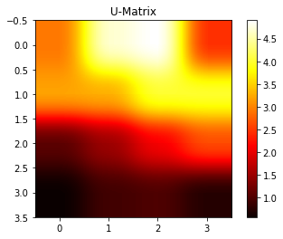

pyclustering

# 8 Forecasting

## 8.1 Fit an ARIMA model to a timeseries.

### a) Plot the timeseries.

```python
# Read in new data set
air = pd.read_csv('/Users/air.csv')

air["DATE"] = pd.to_datetime(air["DATE"], infer_datetime_format = True)
air.index = air["DATE"].values

plt.plot(air.index, air["AIR"])
plt.show()
```

Output:

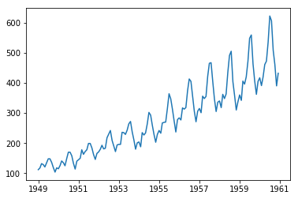

[to_datetime()](https://pandas.pydata.org/pandas-docs/stable/generated/pandas.to_datetime.html)

### b) Fit an ARIMA model and predict 2 years (24 months).

```python
import pyflux as pf

# ar = 12 is necessary to indicate the seasonality of data
model = pf.ARIMA(data = air, ar = 12, ma = 1, integ = 0, target = 'AIR',
                 family = pf.Normal())
x = model.fit("MLE")
model.plot_predict(h = 24)
```

Output:

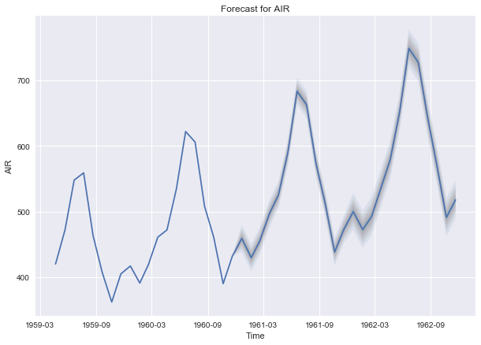

PyFlux

## 8.2 Fit a Simple Exponential Smoothing model to a timeseries.

### a) Plot the timeseries.

```python
# Read in new data set
usecon = pd.read_csv('/Users/usecon.csv')

petrol = usecon["PETROL"]

plt.plot(petrol)
plt.show()
```

Output:

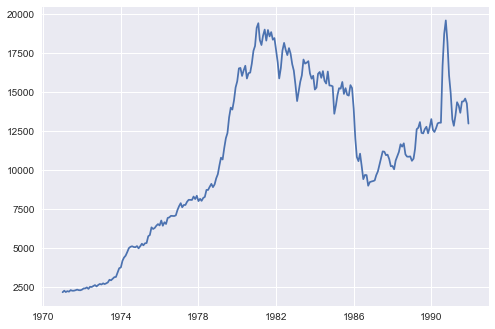

### b) Fit a Simple Exponential Smoothing model, predict 2 years (24 months) out and plot predictions.

Currently, there is not a good package in Python to fit a simple exponential smoothing model. The formula for fitting an exponential smoothing model is not difficult, so we can do it by creating our own functions in Python.

The simplest form of exponential smoothing is given by, where $t > 0$:

$$Eq1: s_0 = x_0$$

$$Eq2: s_t = \alpha x_t + (1 - \alpha)s_{t-1}$$
Therefore, we can implement a simple exponential smoothing model as follows:

```python
def simple_exp_smoothing(data, alpha, n_preds):
    # Eq1:
    output = [data[0]]
    # Smooth given data plus we want to predict 24 units
    # past the end
    for i in range(1, len(data) + n_preds):
        # Eq2:
        if (i < len(data)):
            output.append(alpha * data[i] + (1 - alpha) * data[i-1])
        else:
            output.append(alpha * output[i-1] + (1 - alpha) * output[i-2])
    return output

pred = simple_exp_smoothing(petrol, 0.9999, 24)

plt.plot(pd.DataFrame(pred), color = "red")
plt.plot(petrol, color = "blue")
plt.show()
```

Output:

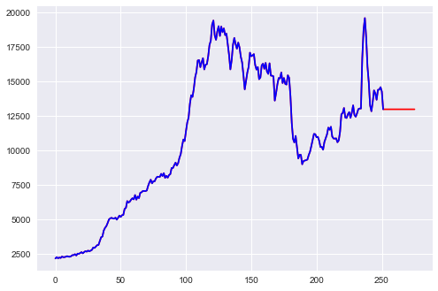

[Basis for code](https://grisha.org/blog/2016/01/29/triple-exponential-smoothing-forecasting/)

## 8.3 Fit a Holt-Winters model to a timeseries.

### a) Plot the timeseries.

```python
vehicle = usecon["VEHICLES"]

plt.plot(vehicle)
plt.show()
```

Output:

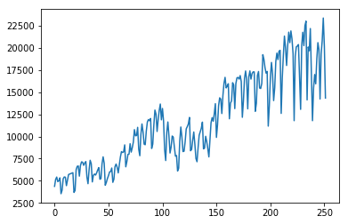

### b) Fit a Holt-Winters additive model, predict 2 years (24 months) out and plot predictions.

Currently, there is not a good package in Python to fit a Holt-Winters additive model. The formula for fitting a Holt-Winters additive model is not difficult, so we can do it by creating our own functions in Python.

The following is an implementation of the Holt-Winters additive model given at [triple exponential smoothing code](https://grisha.org/blog/2016/01/29/triple-exponential-smoothing-forecasting/).

```python
def initial_trend(series, slen):
    sum = 0.0
    for i in range(slen):
        sum += float(series[i+slen] - series[i]) / slen
    return sum / slen
def initial_seasonal_components(series, slen):
    seasonals = {}
    season_averages = []
    n_seasons = int(len(series)/slen)
    # compute season averages
    for j in range(n_seasons):
        season_averages.append(sum(series[slen*j:slen*j+slen])/float(slen))
    # compute initial values
    for i in range(slen):
        sum_of_vals_over_avg = 0.0
        for j in range(n_seasons):
            sum_of_vals_over_avg += series[slen*j+i]-season_averages[j]
        seasonals[i] = sum_of_vals_over_avg/n_seasons
    return seasonals
def triple_exponential_smoothing_add(series, slen, alpha, beta, gamma,
                                     n_preds):
    result = []
    seasonals = initial_seasonal_components(series, slen)
    for i in range(len(series)+n_preds):
        if i == 0: # initial values
            smooth = series[0]
            trend = initial_trend(series, slen)
            result.append(series[0])
            continue
        if i >= len(series): # we are forecasting
            m = i - len(series) + 1
            result.append((smooth + m*trend) + seasonals[i%slen])
        else:
            val = series[i]
            last_smooth, smooth = smooth, alpha*(val-seasonals[i%slen])
                                                 + (1-alpha)*(smooth+trend)
            trend = beta * (smooth-last_smooth) + (1-beta)*trend
            seasonals[i%slen] = gamma*(val-smooth) +
                                (1-gamma)*seasonals[i%slen]
            result.append(smooth+trend+seasonals[i%slen])
    return result

add_preds = triple_exponential_smoothing_add(vehicle, 12, 0.5731265, 0,
                                             0.7230956, 24)

plt.plot(pd.DataFrame(add_preds), color = "red")
plt.plot(vehicle, color = "blue")
plt.show()
```

Output:

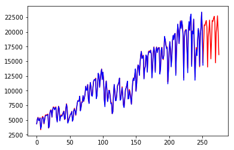

## 8.4 Fit a Facebook Prophet forecasting model to a timeseries.

```python
from fbprophet import Prophet

air = pd.read_csv("/Users/air.csv")

air_df = pd.DataFrame()

air_df["ds"] = pd.to_datetime(air["DATE"], infer_datetime_format = True)
air_df["y"] = air["AIR"]

m = Prophet(yearly_seasonality = True, weekly_seasonality = False)

m.fit(air_df)

future = m.make_future_dataframe(periods = 24, freq = "M")

forecast = m.predict(future)

m.plot(forecast)
```

Output:

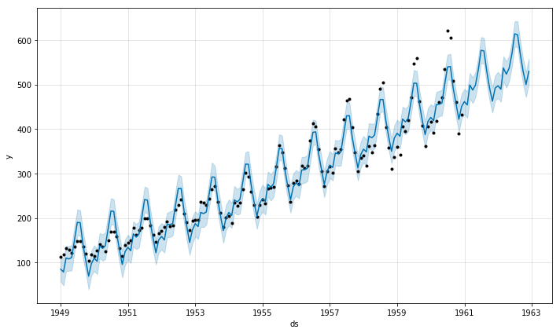

Facebook Prophet Python API

# 9 Model Evaluation & Selection

## 9.1 Evaluate the accuracy of regression models.

### a) Evaluation on training data.

```python
train = pd.read_csv('/Users/boston_train.csv')
test = pd.read_csv('/Users/boston_test.csv')

# Random Forest Regression Model
from sklearn.ensemble import RandomForestRegressor
rfMod = RandomForestRegressor(random_state=29)
rfMod.fit(train.drop(["Target"], axis = 1), train["Target"])

# Evaluation on training data
predY = rfMod.predict(train.drop(["Target"], axis = 1))

# Determine coefficient of determination score
from sklearn.metrics import r2_score
r2_rf = r2_score(train["Target"], predY)
print("Random forest regression model r^2 score (coefficient of determination): %f" % r2_rf)
```

```
## Random forest regression model r^2 score (coefficient of determination): 0.975233
```

### b) Evaluation on testing data.

```python
# Random Forest Regression Model (rfMod)

# Evaluation on testing data
predY = rfMod.predict(test.drop(["Target"], axis = 1))

# Determine coefficient of determination score
r2_rf = r2_score(test["Target"], predY)
print("Random forest regression model r^2 score (coefficient of determination): %f" % r2_rf)
```

```
## Random forest regression model r^2 score (coefficient of determination): 0.833687
```

[RandomForestRegressor](http://scikit-learn.org/stable/modules/generated/sklearn.ensemble.RandomForestRegressor.html)

The sklearn metric [r2_score](http://scikit-learn.org/stable/modules/model_evaluation.html#r2-score-the-coefficient-of-determination) is only one option for assessing a regression model. Please go [here](http://scikit-learn.org/stable/modules/model_evaluation.html#regression-metrics) for more information about other sklearn regression metrics.

## 9.2 Evaluate the accuracy of classification models.

### a) Evaluation on training data.

```python
train = pd.read_csv('/Users/digits_train.csv')
test = pd.read_csv('/Users/digits_test.csv')

# Random Forest Classification Model
from sklearn.ensemble import RandomForestClassifier
rfMod = RandomForestClassifier(random_state=29)
rfMod.fit(train.drop(["Target"], axis = 1), train["Target"])

# Evaluation on training data
predY = rfMod.predict(train.drop(["Target"], axis = 1))

# Determine accuracy score
from sklearn.metrics import accuracy_score
accuracy_rf = accuracy_score(train["Target"], predY)
print("Random forest model accuracy: %f" % accuracy_rf)
```

```
## Random forest model accuracy: 1.000000
```

### b) Evaluation on testing data.

```python
# Random Forest Classification Model (rfMod)

# Evaluation on testing data
predY = rfMod.predict(test.drop(["Target"], axis = 1))

# Determine accuracy score
accuracy_rf = accuracy_score(test["Target"], predY)
print("Random forest model accuracy: %f" % accuracy_rf)
```

```
## Random forest model accuracy: 0.940741
```

[RandomForestClassifier](http://scikit-learn.org/stable/modules/generated/sklearn.ensemble.RandomForestClassifier.html)

Note: The sklearn metric [accuracy_score](http://scikit-learn.org/stable/modules/generated/sklearn.metrics.accuracy_score.html) is only one option for assessing a classification model. Please go [here](http://scikit-learn.org/stable/modules/model_evaluation.html#classification-metrics) for more information about other sklearn classification metrics.

## 9.3 Evaluation with cross validation.

### a) KFold

```python
# Notice we are using a new data set that need to be read into the
# environment
breastcancer = pd.read_csv('/Users/breastcancer.csv')

from sklearn import model_selection
from sklearn.ensemble import RandomForestClassifier

X = breastcancer.drop(["Target"], axis = 1)
Y = breastcancer["Target"]

kfold = model_selection.KFold(n_splits = 5, random_state = 29)
rfMod = RandomForestClassifier(random_state = 29)
results = model_selection.cross_val_score(rfMod, X, Y, cv = kfold)

print("Accuracy: %.2f%% +/- %.2f%%" % (results.mean()*100,
                                       results.std()*100))
```

```
## Accuracy: 94.38% +/- 2.39%
```

[RandomForestClassifier](http://scikit-learn.org/stable/modules/generated/sklearn.ensemble.RandomForestClassifier.html) | [KFold](http://scikit-learn.org/stable/modules/generated/sklearn.model_selection.KFold.html)

### b) ShuffleSplit

```python
shuffle = model_selection.ShuffleSplit(n_splits = 5, random_state = 29)
rfMod = RandomForestClassifier(random_state = 29)
results = model_selection.cross_val_score(rfMod, X, Y, cv = shuffle)

print("Accuracy: %.2f%% +/- %.2f%%" % (results.mean()*100,
                                       results.std()*100))
```

```
## Accuracy: 95.09% +/- 0.70%
```

[RandomForestClassifier](http://scikit-learn.org/stable/modules/generated/sklearn.ensemble.RandomForestClassifier.html) | [ShuffleSplit](http://scikit-learn.org/stable/modules/generated/sklearn.model_selection.ShuffleSplit.html)

# Appendix

## 1 Built-in Python Data Types

- [Boolean](https://docs.python.org/2/library/stdtypes.html#boolean-values)

#### Numeric types

- int
- long
- float
- complex

#### Sequences

- str
- bytes
- byte array
- list
- tuple

#### Sets

- set
- frozen set

#### Mapping:

- dictionary

## 2 Python Plotting Packages

#### [Bokeh](http://bokeh.pydata.org/en/latest/)

A Python package which is useful for interactive visualizations and is optimized for web browser presentations.

#### [PyPlot](https://matplotlib.org/api/pyplot_api.html)

A Python package which is useful for data plotting and visualization.

#### [Seaborn](https://seaborn.pydata.org/)

A Python package which is useful for data plotting and visualization. In particular, Seaborn includes tools for drawing attractive statistical graphics.

## 3 Python packages used in this tutorial

#### [pandas](http://pandas.pydata.org/)

Working with data structures and performing data analysis

#### [NumPy](http://www.numpy.org/)

Scientific and mathematical computing

#### re

Regular expressions

#### [Decimal](https://docs.python.org/2/library/decimal.html)

Tools for decimal floating point arithmetic

#### [sklearn](http://scikit-learn.org/stable/)

scikit-learn, or more commonly known as sklearn, is useful for basic and advanced data mining, machine learning, and data analysis. sklearn includes tools for classification, regression, clustering, dimensionality reduction, model selection, and data pre-processing.

#### [statsmodels.api](http://www.statsmodels.org/stable/index.html)

Tools for the estimation of many different statistical models

#### [xgboost](http://xgboost.readthedocs.io/en/latest/python/python_intro.html)

Extreme gradient boosting models

#### [pyclustering](http://pythonhosted.org/pyclustering/)

Tools for clustering input data

#### [PyFlux](http://www.pyflux.com/docs/)

Tools for time series analysis and prediction

#### [FBProphet](https://facebookincubator.github.io/prophet/docs/quick_start.html#python-api)

Tools for forecasting using the Facebook Prophet model

# Alphabetical Index

## [Array](https://docs.scipy.org/doc/numpy/reference/generated/numpy.array.html)

A NumPy array is a data type in which the elements of the array are all of the same type. Please see the following example of array creation and access:

```python
import numpy as np
my_array = np.array([1, 2, 3, 4])
print(my_array)
```

```
## [1 2 3 4]
```

```python
print(my_array[3])
```

```
## 4
```

## Bytes & Byte arrays

A [byte](https://docs.python.org/3.1/library/functions.html#bytes) is a sequence of integers which is immutable, whereas a [byte array](https://docs.python.org/3.1/library/functions.html#bytearray) is its mutable counterpart.

## [Data Frame](http://pandas.pydata.org/pandas-docs/stable/generated/pandas.DataFrame.html)

A two-dimensional tabular structure with labeled axes (rows and columns), where data observations are represented by rows and data variables are represented by columns.

## [Dictionary](https://docs.python.org/2/tutorial/datastructures.html#dictionaries)

An associative array which is indexed by keys which map to values. Therefore, a dictionary is an unordered set of key:value pairs where each key is unique. Please see the following example of dictionary creation and access:

```python
import pandas as pd
student = pd.read_csv('/Users/class.csv')
for_dict = pd.concat([student["Name"], student["Age"]], axis = 1)
class_dict = for_dict.set_index('Name').T.to_dict('list')
print(class_dict.get('James'))
```

```
## [12]
```

## [List](https://www.tutorialspoint.com/python/python_lists.htm)

A sequence of comma-separated objects that need not be of the same type. Please see the following example of list creation and access:

```python
list1 = ['item1', 102]
print(list1)
```

```
## ['item1', 102]
```

```python
print(list1[1])
```

```
## 102
```

Python also has what are known as [“Tuples”](https://www.tutorialspoint.com/python/python_tuples.htm), which are immutable lists created in the same way as lists, except with paranthesis instead of brackets.

## [Series](https://pandas.pydata.org/pandas-docs/stable/dsintro.html)

A one-dimensional data frame. Please see the following example of Series creation and access:

```python
import pandas as pd
my_array = pd.Series([1, 3, 5, 9])
print(my_array)
```

```
## 0    1
## 1    3
## 2    5
## 3    9
## dtype: int64
```

```python
print(my_array[1])
```

```
## 3
```

## Sets & Frozen Sets

A set is a unordered collection of immutable objects. The difference between a [set and a frozen set](http://www.python-course.eu/sets_frozensets.php) is that the former is mutable, while the latter is immutable. Please see the following example of set and frozen set creation and access:

```python
s = set(["1", "2", "3"])
# s is a set, which means you can add or delete elements from s
print(s)
```

```
## {'2', '1', '3'}
```

```python
s.add("4")
print(s)
```

```
## {'1', '3', '4', '2'}
```

```python
fs = frozenset(["1", "2", "3"])
# fs is a frozenset, which means you cannot add or delete elements from fs
print(fs)
```

```
## frozenset({'3', '1', '2'})
```

## [str](https://www.tutorialspoint.com/python/python_strings.htm)

A list of characters, though characters are not a type in Python, but rather a string of length 1. Strings are indexable like arrays. Please see the following example of String creation and access:

```python
s = 'My first string!'
print(s)
```

```
## My first string!
```

```python
print(s[5])
```

```
## r
```

For more information on Python packages and functions, along with helpful examples, please see [Python](https://www.python.org/).